# p8105_hw2_fc2691

FC

10/3/2021

## Problem 1

This problem uses the Mr. Trash Wheel dataset, available as an Excel file on the course website.

Read and clean the Mr. Trash Wheel sheet:

- specify the sheet in the Excel file and to omit non-data entries (rows with notes / figures; columns containing notes) using arguments in read_excel
- use reasonable variable names
- omit rows that do not include dumpster-specific data
- round the number of sports balls to the nearest integer

Read and clean precipitation data for 2018 and 2019. For each, omit rows without precipitation data and add a variable for year. Next, combine precipitation datasets and convert month to a character variable (the variable month.name is built into R and should be useful).

Write a paragraph about these data; you are encouraged to use inline R. Be sure to note the number of observations in both resulting datasets, and give examples of key variables. For available data, what was the total precipitation in 2018? What was the median number of sports balls in a dumpster in 2019?

```r
library(readxl)
library(tidyverse)
library(dplyr)
library(tidyr)

#Clean the data in Mr. Trash Wheel Sheet.
mr_trash_wheel_sheet =
  readxl::read_excel("./data/Trash-Wheel-Collection-Totals-7-2020-2.xlsx", range = "A2:N534") %>%
  janitor::clean_names() %>%
  drop_na(dumpster) %>%
  mutate(sports_balls = round(sports_balls,0))

mr_trash_wheel_sheet
```

```
## # A tibble: 453 × 14
##    dumpster month  year date                weight_tons volume_cubic_yards
##       <dbl> <chr> <dbl> <dttm>                    <dbl>              <dbl>
##  1        1 May    2014 2014-05-16 00:00:00        4.31                 18
##  2        2 May    2014 2014-05-16 00:00:00        2.74                 13
##  3        3 May    2014 2014-05-16 00:00:00        3.45                 15
##  4        4 May    2014 2014-05-17 00:00:00        3.1                  15
##  5        5 May    2014 2014-05-17 00:00:00        4.06                 18
##  6        6 May    2014 2014-05-20 00:00:00        2.71                 13
##  7        7 May    2014 2014-05-21 00:00:00        1.91                  8
##  8        8 May    2014 2014-05-28 00:00:00        3.7                  16
##  9        9 June   2014 2014-06-05 00:00:00        2.52                 14
## 10       10 June   2014 2014-06-11 00:00:00        3.76                 18
## # … with 443 more rows, and 8 more variables: plastic_bottles <dbl>,
## #   polystyrene <dbl>, cigarette_butts <dbl>, glass_bottles <dbl>,
## #   grocery_bags <dbl>, chip_bags <dbl>, sports_balls <dbl>,
## #   homes_powered <dbl>
```

```r
#clean precipitation data for 2018 and 2019

#Reorganize precipitation data for 2018
precipitation_data_2018 =
  readxl::read_excel("./data/Trash-Wheel-Collection-Totals-7-2020-2.xlsx", sheet = "2018 Precipitation", range = "A2:B15") %>%
  janitor::clean_names() %>%
  drop_na() %>%
  mutate(year = 2018)

##Reorganize precipitation data for 2019
precipitation_data_2019 =
  readxl::read_excel("./data/Trash-Wheel-Collection-Totals-7-2020-2.xlsx", sheet = "2019 Precipitation", range = "A2:B15") %>%
  janitor::clean_names() %>%
  drop_na() %>%
  mutate(year = 2019)

precipitation_data_clean =
  full_join(
    precipitation_data_2018, precipitation_data_2019
  ) %>%
  mutate(month = month.name[month]) %>%
  relocate(year, month, total)
precipitation_data_clean
```

```
## # A tibble: 24 × 3
##     year month     total
##    <dbl> <chr>     <dbl>
##  1  2018 January    0.94
##  2  2018 February   4.8
##  3  2018 March      2.69
##  4  2018 April      4.69
##  5  2018 May        9.27
##  6  2018 June       4.77
##  7  2018 July      10.2
##  8  2018 August     6.45
##  9  2018 September 10.5
## 10  2018 October    2.12
## # … with 14 more rows
```

In Mr.Trash Wheel sheet, there are data from 2014 to 2021 with 14 variables and 453 observations. In the joint precipitation data for 2018 and 2019, there are 24 observations and 3 variables Among those data, it could be concluded that the total precipitation in 2018 is 70.33. The median number of sports balls in dumpster in 2019 is 9.

## Problem 2

This problem uses the *FiveThirtyEight* data; these data were gathered to create the interactive graphic on this page.

- First, clean the data in pols-month.csv. Use separate() to break up the variable mon into integer variables year, month, and day; replace month number with month name; create a president variable taking values gop and dem, and remove prez_dem and prez_gop; and remove the day variable.
- Second, clean the data in snp.csv using a similar process to the above. For consistency across datasets, arrange according to year and month, and organize so that year and month are the leading columns.
- Third, tidy the unemployment data so that it can be merged with the previous datasets. This process will involve switching from “wide” to “long” format; ensuring that key variables have the same name; and ensuring that key variables take the same values.
- Join the datasets by merging snp into pols, and merging unemployment into the result.

```
## # A tibble: 822 × 9
##    year  month gov_gop sen_gop rep_gop gov_dem sen_dem rep_dem president
##    <chr> <chr>   <dbl>   <dbl>   <dbl>   <dbl>   <dbl>   <dbl> <chr>
##  1 1947  Jan        23      51     253      23      45     198 dem
##  2 1947  Feb        23      51     253      23      45     198 dem
##  3 1947  Mar        23      51     253      23      45     198 dem
##  4 1947  Apr        23      51     253      23      45     198 dem
##  5 1947  May        23      51     253      23      45     198 dem
##  6 1947  Jun        23      51     253      23      45     198 dem
##  7 1947  Jul        23      51     253      23      45     198 dem
##  8 1947  Aug        23      51     253      23      45     198 dem
##  9 1947  Sep        23      51     253      23      45     198 dem
## 10 1947  Oct        23      51     253      23      45     198 dem
## # … with 812 more rows
```

```
## # A tibble: 787 × 3
##    year  month close
##    <chr> <chr> <dbl>
##  1 1950  Apr    18
##  2 1950  Aug    18.4
##  3 1950  Dec    20.4
##  4 1950  Feb    17.2
##  5 1950  Jan    17
##  6 1950  Jul    17.8
##  7 1950  Jun    17.7
##  8 1950  Mar    17.3
##  9 1950  May    18.8
## 10 1950  Nov    19.5
## # … with 777 more rows
```

```
## # A tibble: 816 × 3
##    year  month unemployment_data
##    <chr> <chr>             <dbl>
##  1 1948  Jan                 3.4
##  2 1948  Feb                 3.8
##  3 1948  Mar                 4
##  4 1948  Apr                 3.9
##  5 1948  May                 3.5
##  6 1948  Jun                 3.6
##  7 1948  Jul                 3.6
##  8 1948  Aug                 3.9
##  9 1948  Sep                 3.8
## 10 1948  Oct                 3.7
## # … with 806 more rows
```

```
## # A tibble: 822 × 11
##    year  month gov_gop sen_gop rep_gop gov_dem sen_dem rep_dem president close
##    <chr> <chr>   <dbl>   <dbl>   <dbl>   <dbl>   <dbl>   <dbl> <chr>     <dbl>
##  1 1947  Jan        23      51     253      23      45     198 dem          NA
##  2 1947  Feb        23      51     253      23      45     198 dem          NA
##  3 1947  Mar        23      51     253      23      45     198 dem          NA
##  4 1947  Apr        23      51     253      23      45     198 dem          NA
##  5 1947  May        23      51     253      23      45     198 dem          NA
##  6 1947  Jun        23      51     253      23      45     198 dem          NA
##  7 1947  Jul        23      51     253      23      45     198 dem          NA
##  8 1947  Aug        23      51     253      23      45     198 dem          NA
##  9 1947  Sep        23      51     253      23      45     198 dem          NA
## 10 1947  Oct        23      51     253      23      45     198 dem          NA
## # … with 812 more rows, and 1 more variable: unemployment_data <dbl>
```

pols-month.csv decribes the number of national politicians who are democratic or repunlican at any given time which including 822 observations and 9 variables. snp.csv describes the closing values of the Standard & Poor’s stock market index on the associated date with 787 observations and 3 variables. During tidy process, the date was seperate to specific year and month. Unemployment.csv describes the percentage of unemployment in each month of the associated year. While changing months from columns to rows, it includes 816 observations. After joining these three tables, the final dimension of table is (822, 11), the range of years is [1947, 2015]. The tables were joined using key variables year and month.

## Problem 3

Load and tidy the data.  
Produce a well-structured, reader-friendly table showing the rank in popularity of the name “Olivia” as a female baby name over time; this should have rows for ethnicities and columns for year. Produce a similar table showing the most popular name among male children over time.

Finally, for male, white non-hispanic children born in 2016, produce a scatter plot showing the number of children with a name (y axis) against the rank in popularity of that name (x axis).

```r
# Load the data and remove the duplicates.
library(ggplot2)
popular_baby_names_base =
  read_csv("./data/Popular_Baby_Names.csv") %>%
  janitor::clean_names() %>%
  mutate(
    gender = str_to_title(gender),
    ethnicity = str_to_title(ethnicity),
    childs_first_name = str_to_title(childs_first_name)
    ) %>%
  distinct()
popular_olivia_names = popular_baby_names_base %>%
  #Showing the rank in popularity of the name “Olivia” as a female baby name over time
  filter(gender == "Female" & childs_first_name == "Olivia") %>%
  select(-gender, -childs_first_name) %>%
  pivot_wider(
    names_from = c(ethnicity),
    values_from = c(year_of_birth)
    ) %>%
  relocate(rank, count, everything()) %>%
  knitr::kable(caption = "The popularity of the name 'Olivia' as a female baby over time")
popular_olivia_names
```

The popularity of the name ‘Olivia’ as a female baby over time

| rank | count | Asian And Pacific Islander | Black Non Hispanic | Hispanic | White Non Hispanic | Asian And Paci | Black Non Hisp | White Non Hisp |
| --- | --- | --- | --- | --- | --- | --- | --- | --- |
| 1 | 172 | 2016 | NA | NA | NA | NA | NA | NA |
| 8 | 49 | NA | 2016 | NA | NA | NA | NA | NA |
| 13 | 108 | NA | NA | 2016 | NA | NA | NA | NA |
| 1 | 230 | NA | NA | NA | 2016 | NA | NA | NA |
| 1 | 188 | 2015 | NA | NA | NA | NA | NA | NA |
| 4 | 82 | NA | 2015 | NA | NA | NA | NA | NA |
| 16 | 94 | NA | NA | 2015 | NA | NA | NA | NA |
| 1 | 225 | NA | NA | NA | 2015 | NA | NA | NA |
| 1 | 141 | 2014 | NA | NA | NA | NA | NA | NA |
| 8 | 52 | NA | 2014 | NA | NA | NA | NA | NA |
| 16 | 96 | NA | NA | 2014 | NA | NA | NA | NA |
| 1 | 248 | NA | NA | NA | 2014 | NA | NA | NA |
| 3 | 109 | 2013 | NA | NA | NA | NA | NA | NA |
| 6 | 64 | NA | 2013 | NA | NA | NA | NA | NA |
| 22 | 87 | NA | NA | 2013 | NA | NA | NA | NA |
| 1 | 233 | NA | NA | NA | 2013 | NA | NA | NA |
| 3 | 132 | NA | NA | NA | NA | 2012 | NA | NA |
| 8 | 58 | NA | NA | NA | NA | NA | 2012 | NA |
| 22 | 77 | NA | NA | 2012 | NA | NA | NA | NA |
| 4 | 198 | NA | NA | NA | NA | NA | NA | 2012 |
| 4 | 89 | 2011 | NA | NA | NA | NA | NA | NA |
| 10 | 52 | NA | 2011 | NA | NA | NA | NA | NA |
| 18 | 86 | NA | NA | 2011 | NA | NA | NA | NA |
| 2 | 213 | NA | NA | NA | 2011 | NA | NA | NA |

```r
popular_male_baby_names_count = popular_baby_names_base %>%
  filter(gender == "Male") %>%
  group_by(childs_first_name) %>%
  summarise(
    total_count = sum(count),
    rank_avg = mean(rank)
    ) %>%
  arrange(rank_avg, desc(total_count))
popular_male_baby_names_count
```

```
## # A tibble: 830 × 3
##    childs_first_name total_count rank_avg
##    <chr>                   <dbl>    <dbl>
##  1 Moshe                    1484     4.33
##  2 Ethan                    4245     7.83
##  3 Jacob                    3994    11.6
##  4 Daniel                   3463    11.6
##  5 Matthew                  3327    14.2
##  6 Liam                     3226    15.1
##  7 Noah                     3231    15.2
##  8 Michael                  3279    15.3
##  9 Aiden                    3155    16.2
## 10 Alexander                3059    17.2
## # … with 820 more rows
```

```r
# From the table above, "Ethan" seems like the most popular name among male children over time.
popularity_ethan_male_names = popular_baby_names_base %>%
  filter(gender == "Male" & childs_first_name == "Ethan") %>%
  select(-gender, -childs_first_name) %>%
  pivot_wider(
    names_from = c(ethnicity),
    values_from = c(year_of_birth)
    ) %>%
  relocate(rank, count, everything()) %>%
  knitr::kable(caption = "The popularity of the name 'Ethan' as a male baby over time")
popularity_ethan_male_names
```

The popularity of the name ‘Ethan’ as a male baby over time

| rank | count | Asian And Pacific Islander | Black Non Hispanic | Hispanic | White Non Hispanic | Asian And Paci | Black Non Hisp | White Non Hisp |
| --- | --- | --- | --- | --- | --- | --- | --- | --- |
| 1 | 193 | 2016 | NA | NA | NA | NA | NA | NA |
| 5 | 107 | NA | 2016 | NA | NA | NA | NA | NA |
| 7 | 250 | NA | NA | 2016 | NA | NA | NA | NA |
| 20 | 133 | NA | NA | NA | 2016 | NA | NA | NA |
| 2 | 172 | 2015 | NA | NA | NA | NA | NA | NA |
| 5 | 111 | NA | 2015 | NA | NA | NA | NA | NA |
| 3 | 332 | NA | NA | 2015 | NA | NA | NA | NA |
| 19 | 138 | NA | NA | NA | 2015 | NA | NA | NA |
| 2 | 179 | 2014 | NA | NA | NA | NA | NA | NA |
| 1 | 138 | NA | 2014 | NA | NA | NA | NA | NA |
| 5 | 262 | NA | NA | 2014 | NA | NA | NA | NA |
| 18 | 149 | NA | NA | NA | 2014 | NA | NA | NA |
| 2 | 165 | 2013 | NA | NA | NA | NA | NA | NA |
| 1 | 146 | NA | 2013 | NA | NA | NA | NA | NA |
| 5 | 252 | NA | NA | 2013 | NA | NA | NA | NA |
| 23 | 125 | NA | NA | NA | 2013 | NA | NA | NA |
| 2 | 187 | NA | NA | NA | NA | 2012 | NA | NA |
| 3 | 151 | NA | NA | NA | NA | NA | 2012 | NA |
| 4 | 254 | NA | NA | 2012 | NA | NA | NA | NA |
| 21 | 131 | NA | NA | NA | NA | NA | NA | 2012 |
| 1 | 177 | 2011 | NA | NA | NA | NA | NA | NA |
| 6 | 124 | NA | 2011 | NA | NA | NA | NA | NA |
| 6 | 251 | NA | NA | 2011 | NA | NA | NA | NA |
| 26 | 118 | NA | NA | NA | 2011 | NA | NA | NA |

```r
popular_baby_names_base
```

```
## # A tibble: 12,181 × 6
##    year_of_birth gender ethnicity                  childs_first_name count  rank
##            <dbl> <chr>  <chr>                      <chr>             <dbl> <dbl>
##  1          2016 Female Asian And Pacific Islander Olivia              172     1
##  2          2016 Female Asian And Pacific Islander Chloe               112     2
##  3          2016 Female Asian And Pacific Islander Sophia              104     3
##  4          2016 Female Asian And Pacific Islander Emily                99     4
##  5          2016 Female Asian And Pacific Islander Emma                 99     4
##  6          2016 Female Asian And Pacific Islander Mia                  79     5
##  7          2016 Female Asian And Pacific Islander Charlotte            59     6
##  8          2016 Female Asian And Pacific Islander Sarah                57     7
##  9          2016 Female Asian And Pacific Islander Isabella             56     8
## 10          2016 Female Asian And Pacific Islander Hannah               56     8
## # … with 12,171 more rows
```

```r
scatter_plot_male_white_non_hispanic = popular_baby_names_base %>%
  filter(gender == "Male" & ethnicity == "White Non Hispanic" & year_of_birth == 2016) %>%
  select(-year_of_birth, -gender, -ethnicity)
scatter_plot_male_white_non_hispanic
```

```
## # A tibble: 364 × 3
##    childs_first_name count  rank
##    <chr>             <dbl> <dbl>
##  1 Joseph              261     1
##  2 Michael             260     2
##  3 David               255     3
##  4 Moshe               239     4
##  5 Jacob               236     5
##  6 James               231     6
##  7 Benjamin            219     7
##  8 Alexander           211     8
##  9 Daniel              196     9
## 10 Henry               196     9
## # … with 354 more rows
```

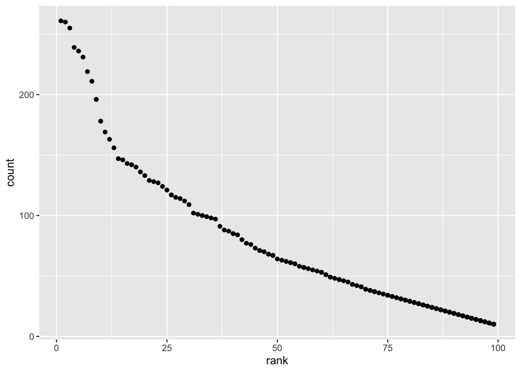

```r
ggplot(scatter_plot_male_white_non_hispanic, aes(x = rank, y = count)) + geom_point()
```